# IRSS Coffee tasking

# IRSS coffee tasting

Today we are trying 6 unique varieties of coffee from Oso Negro coffee roasters in Nelson, BC. These coffees have been ground for brewing in a french press. We will try two coffees at a time. At the end of the coffee tasting you will blind rate your favorite coffee and we will look at the results. Below is a synopsis of the coffees we are trying and where the beans of each variety are sourced from.

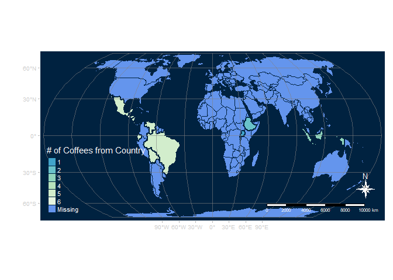

## Road Rider

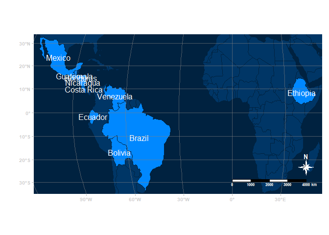

*light roast*

## Low acid

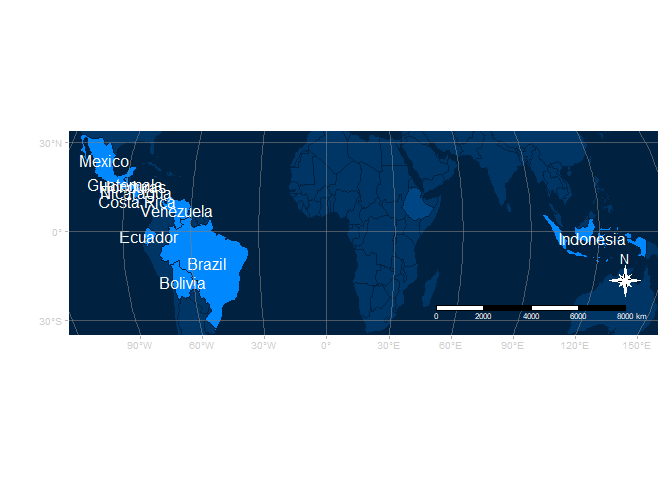

*medium roast*

The Low Acid Blend features smooth coffee from Central and South America and mildly nutty Sumatran beans. The result is a subtly earthy blend with a clean, sweet aftertaste.

## Messy Room

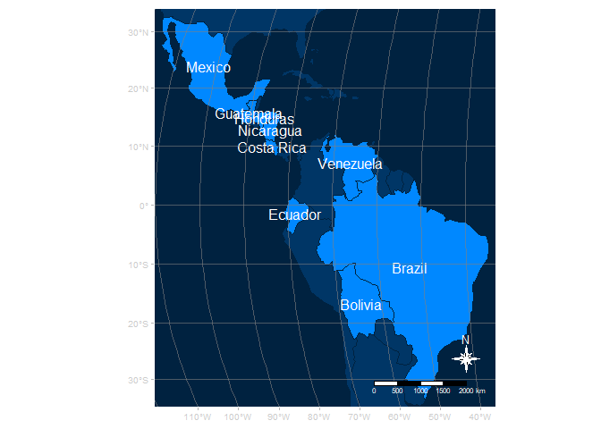

*dark roast*

## Princess of Darkness

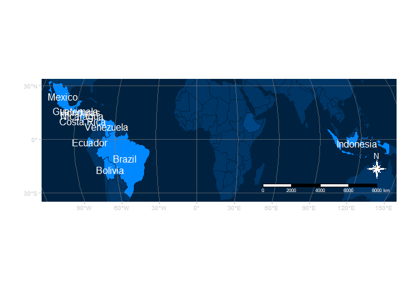

*very dark roast*

The Princess of Darkness Blend provides a big, clean mouth feel, smooth butteriness and a hint of rich savoury nut. Our darkest blend, still faintly sweet like caramel – the Princess is a great choice for making a powerful dark drip.

## Justicia

[interactive chart not shown]

*medium roast single-origin*

Guatemalan coffee grown on the slopes of lake Atitlan in Guatemala.

## Royal Select

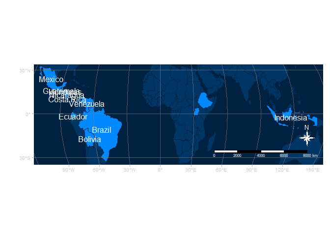

Royal Select Decaf is a product of a water decaffeination process that retains as much flavour as possible creating a coffee that is very layered, deftly balanced and hard to distinguish from regular coffee.

## Fill out the form :

[IRSS Coffee Tasting Response Form](https://forms.gle/CUk3K5L2pQDHqBkq5)